RESEARCH ARTICLE

Open Access

Effect of fecal microbiota transplant on

symptoms of psychiatric disorders: a

systematic review

Arthi Chinna Meyyappan<sup>1,2,3*</sup>

, Evan Forth<sup>1,2,3</sup>, Caroline J. K. Wallace<sup>1,2,3</sup>and Roumen Milev<sup>1,2,3,4</sup>

Abstract

Background: The Gut-Brain-Axis is a bidirectional signaling pathway between the gastrointestinal (GI) tract and the

brain. The hundreds of trillions of microorganisms populating the gastrointestinal tract are thought to modulate

this connection, and have far reaching effects on the immune system, central and autonomic nervous systems, and

various psychiatric illnesses such as depression, anxiety, substance abuse, autism spectrum disorder, and eating

disorders. It is hypothesized that techniques aimed at strengthening and repopulating the gut microbiome, such as

Fecal Microbiota Transplant (FMT), may be useful in the prevention and treatment of psychiatric illnesses.

Methods: A systematic search of five databases was conducted using key terms related to FMT and psychiatric

illnesses. All results were then evaluated based on specific eligibility criteria.

anxiety-like symptoms and behaviours resulting from the transplantation of healthy microbiota. The inverse was

also found, with the transmission of depressive and anxiety-like symptoms and behaviours resulting from the

transplantation of microbiota from psychiatrically ill donors to healthy recipients.

Conclusion: There appears to be strong evidence for the treatment and transmission of psychiatric illnesses

through FMT. Further research with larger sample sizes and stronger scientific design is warranted in order to fully

determine the efficacy and safety of this potential treatment. Registered on PROSPERO, IRD: CRD42019126795.

Keywords: Fecal microbiota transplant, Gut-brain axis, Psychiatric illness, Depression, Anxiety, Eating disorders,

Substance abuse, Chronic stress

[figure not shown]

© The Author(s). 2020 Open Access This article is licensed under a Creative Commons Attribution 4.0 International License,

which permits use, sharing, adaptation, distribution and reproduction in any medium or format, as long as you give

appropriate credit to the original author(s) and the source, provide a link to the Creative Commons licence, and indicate if

changes were made. The images or other third party material in this article are included in the article's Creative Commons

licence, unless indicated otherwise in a credit line to the material. If material is not included in the article's Creative Commons

licence and your intended use is not permitted by statutory regulation or exceeds the permitted use, you will need to obtain

permission directly from the copyright holder. To view a copy of this licence, visit http://creativecommons.org/licenses/by/4.0/.

The Creative Commons Public Domain Dedication waiver (http://creativecommons.org/publicdomain/zero/1.0/) applies to the

data made available in this article, unless otherwise stated in a credit line to the data.

* Correspondence: 14acm@queensu.ca

1Department of Psychiatry, Queen’s University, 752 King St. West, Kingston,

ON K7L 4X3, Canada

2Providence Care Hospital, 752 King St. West, Kingston, ON K7L 4X3, Canada

Full list of author information is available at the end of the article

[figure not shown]

Chinna Meyyappan et al. BMC Psychiatry (2020) 20:299

https://doi.org/10.1186/s12888-020-02654-5

Background

In recent years, there has been a growing appreciation for

research in the field of the “gut-brain axis” (GBA). The

GBA consists of bidirectional biochemical and neural sig-

nalling between the gastrointestinal (GI) tract and the

brain. Specifically, the gut microbiota is able to modulate

the GBA both directly and indirectly via endocrine, neural,

and immune pathways. In disease- or stress-states these

pathways may become compromised resulting in intestinal

dysbiosis, changes in mood, behavior, and cognition, and

altered inflammatory levels [1].

The gastrointestinal tract is colonized by over one hun-

dred trillion commensal bacteria that exist symbiotically

with our bodies. Colonization of the gut occurs at birth

and is largely influenced by mode of delivery (c-section vs.

vaginal birth) and through breast feeding. However,

bacterial composition of the gut begins to stabilize

throughout adulthood [2]. Detailed analyses of human gut

microbiota have shown considerable individual variability

in bacterial content as this dynamic system is influenced

by a variety of factors, such as genetics, diet, metabolism,

age, geography, antibiotic treatment, psychotropics, and

stress [3, 4].

Gut microbiota are critical in the normal develop-

ment of the immune system, central nervous system

(CNS) circuitry, GI functioning, and autonomic ner-

vous system (ANS) functioning. This community of

bacteria and its genetic material is often referred to as

a virtual organ [4–6]. Studies have since shown that

gut bacteria play a vital role in regulating important as-

pects of brain development and function, along with

other host physiology [5, 7].

The gut and psychiatric symptoms and disorders

The interaction of the gut with the environmental risk

factors of psychiatric illnesses, such as diet and early life

stress, suggests that interventions targeting the gut

microbiome could prevent and treat psychiatric symp-

toms [8]. Psychiatric symptoms can manifest in both

psychological and physiological ways, often resulting in

impaired functioning. Common physiological symptoms

share similarities with symptoms of GI disorders, such

as Irritable Bowel Syndrome (IBS). This association may

be explained by the close connection between the gut

and the brain.

In past studies, individuals with psychiatric illness have

also been shown to have a dissimilar microbiota com-

position compared to healthy individuals, due to de-

creased diversity and abundance of the healthy gut

microbes [9]. Studies also show that lack of exposure to

commensal bacteria, such as in germ-free mice, has sig-

nificant effects on stress responsiveness in adulthood; it

has also been shown that early colonization of the gut

with a conventional microbiota, even a single species,

can partially reverse these effects [10]. Some investiga-

tions have shown neurochemical changes as a result of

gut microbiome dysfunction, such as altered levels of

brain-derived neurotropic factor (BDNF), reduced sero-

tonin receptor expression, reduced synaptic plasticity

gene expression, and increased striatal monoamine turn-

over [10–12].

Fecal microbiota transplant

Several methods of examining the influence of the gut

microbiome on the gut-brain axis have been explored,

including manipulating the microbiome via probiotic

and antibiotic administration, the use of germ-free ani-

mal models, and perhaps most notably, fecal microbiota

transplantation (FMT). FMT is the transfer of fecal bac-

teria from a healthy donor to a recipient. FMT was first

used in fourth century China for the treatment of severe

food poisoning and diarrhea and other related symptoms

[13]. However, it is currently only indicated for the treat-

ment of Clostridium difficile (C. difficile.) infections. C.

difficile is often contracted by older patients in-hospital

following routine pharmacological treatments such as

antibiotics. The use of antibiotics often depletes healthy

bacteria in the GI tract which can result in microbial

dysfunction. FMT is used to restore healthy status of the

microbiome via repopulation of healthy bacteria to the

gut. Functioning in a similar manner to probiotics, this

treatment method helps to maintain the bacterial bal-

ance and function. FMT are most commonly accom-

plished via endoscopies, enemas, and oral feeding of

freeze-dried material. Aside from GI and psychiatric dis-

orders, this treatment method is also being explored as a

potential treatment for metabolic disorders, autism, mul-

tiple sclerosis, and Parkinson’s disease [14–17]. Other

variations of this treatment, such as Microbial Ecosystem

Therapeutics-2 (MET-2) are also currently being ex-

plored, in psychiatric indications such as Generalized

Anxiety (GAD) and Major Depressive Disorders (MDD).

MET-2 consists of gut bacteria obtained from stool sam-

ples of a healthy donor, chosen for its safety profile, that

is then purified and lab-grown prior to being lyophilized

and ingested orally by patients [18].

FMT in the context of psychiatric illness

Two of the most prevalent groups of psychiatric disor-

ders include Major Depressive Disorder and anxiety dis-

orders. MDD is characterized by either depressed mood

and/or loss of interest or pleasure, as well other psychi-

atric and physiological symptoms. Anxiety disorders is a

category that includes a variety of disorders character-

ized by intense feelings of anxiety, nervousness, or fear.

These include Generalized Anxiety Disorder, Agorapho-

bia, Panic Disorder, and specific phobias. Both groups of

disorders are characterized by a significant impairment

Chinna Meyyappan et al. BMC Psychiatry (2020) 20:299

Page 2 of 19

in daily functioning [19]. While there are pharmaco-

logical treatments available for both disorders, many

people deny treatment due to side effects or stigma-

related reasons or are treatment-resistant and unable to

find an effective way to improve their symptoms. By tar-

geting the gut, FMT may be a potential way to overcome

these drawbacks. Research on the gut-brain axis indi-

cates that there may be a possibility to improve these

symptoms through restoration of the gut microbiome

via fecal transplant from a healthy donor. However, as

this is a relatively novel area of research, there are few

studies on FMT in humans as a treatment method in

the context of psychiatric disorders.

This review examines findings from preclinical and clin-

ical studies that have examined the effects of endogenous

microbiome transfer on psychiatric symptoms. The stud-

ies included in this review assess the effects of FMT and

related interventions on symptoms associated with a var-

iety of psychiatric illnesses including MDD, anxiety, and

chronic stress. Comorbid disorders associated with poor

mental health outcomes such as alcoholism and anorexia

were also included in several of the studies.

Methods

Literature search strategy

This review adhered to the Preferred Reporting Items

for Systematic Reviews and Meta-Analyses (PRISMA)

guidelines (Fig. 1, [20]). Relevant studies were identified

by systematically searching the following databases:

MEDLINE, EMBASE, CINAHL, PsycINFO, and Web of

Science using key search terms including: mood, anxiety,

mania, stress, phobia, microbiota transfer, and fecal

transplant. The strategy adapted to each of the databases

listed above and is described in detail in Appendix 1.

Searches were conducted in November 2019 and yielded

full-text screening. Any studies that were excluded dur-

ing full-text screening were due to wrong study design

or outcomes. Reasons for which articles were rejected

on the basis of ‘wrong study design’ include the article

being a review paper or only an abstract. Those that

were rejected due to “wrong study outcome” did not

measure any clinical symptoms directly related to psy-

chiatric illness.

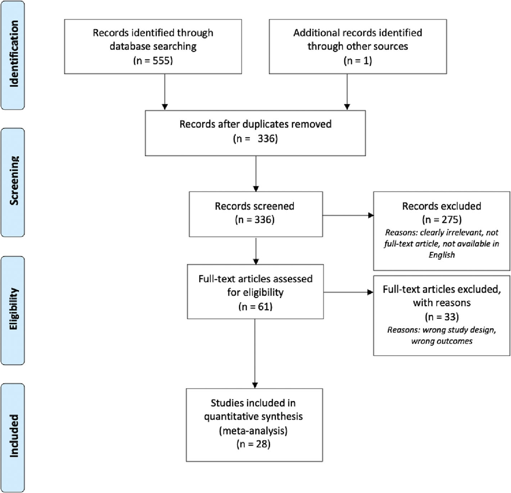

Fig. 1 Flow chart showing literature search and screening process using PRISMA process

Chinna Meyyappan et al. BMC Psychiatry (2020) 20:299

Page 3 of 19

Eligibility criteria

All articles eligible for inclusion were published in peer-

reviewed journals and were written in English. The stud-

ies were restricted to preclinical or clinical samples that

were assessed for changes in symptoms of psychiatric ill-

ness after undergoing an endogenous microbe transfer

via any route of administration.

Study selection

One author (A.C.M) completed initial search of the data-

bases, adhering to the search strategy (Appendix 1). Two

authors (A.C.M and C.W) independently assessed the ti-

tles and abstracts of records retrieved from the systematic

search according to the identified inclusion and exclusion

criteria and completed the full-text review. Any disagree-

ments were resolved by a third author (R.M).

Study quality

The Cochrane Handbook for Systematic Reviews of Inter-

ventions Risk of Bias Tool (RoBT) addresses 6 specific do-

mains in assessing the quality of randomized controlled

trials: sequence generation, allocation concealment, blind-

ing, incomplete outcome data, selective outcome reporting

and ‘other issues’. All included studies were analyzed ac-

cording to these domains by A.C.M and C.W. As there is

limited research on this topic, studies that did not follow

the double-blind, randomized controlled model, were in-

cluded if they had a comprehensive methodology after

thorough analysis by three of the authors (A.C.M., C.W.,

and R.M.). Overall, the included studies presented with

low levels of potential bias save for cases where blinding

of either the participant or study team was not performed.

For these cases, bias was assessed as high. Detailed assess-

ments can be found in Table 1. Allocation concealment

was not assessed since no studies concealed treatment al-

location from subjects or participants.

Results

Study characteristics

This review contains 28 studies evaluating the effect of

fecal microbiota transplants on various psychiatric and

physical symptoms. Of these, eleven studies examined

exclusively animal samples, nine studies were preclinical

subjects with transplanted microbiota from human do-

nors, and eight studies examined exclusively human

samples. The characteristics of these studies are dis-

played in Tables 2, 3, and 4. The average sample size

was n = 23 for entirely preclinical studies, and n = 78 for

preclinical studies with human donors, and n = 19 for

clinical studies. Four of the preclinical studies failed to

report rodent sample size. The symptoms most fre-

quently studied were that of Irritable Bowel Syndrome

(IBS), chronic stress, and depressive-like symptoms.

Preclinical studies

In the eleven preclinical studies included in this review

(Table 2), the primary indications investigated were chronic

stress (n = 6), alcoholism (n = 2), chronic neuropathic pain

(n = 2), and depression (n = 1). Of the studies assessing

chronic stress, three investigated the effects of FMT from

mice subjected to the chronic unpredictable mild stress

(CUMS) procedure to healthy mice, one replicated this

using the social defeat model of stress in rats, one investi-

gated the effects of fecal transplant from healthy mice to

stressed mice, and one investigated the effects of FMT from

NLPR3 knockout mice on the resiliency of mice subjected

to the CUMS procedure after fecal transplant. When inves-

tigating the effects of FMT from CUMS mice to germ free

mice, three studies found that the FMT resulted in in-

creased anxiety and depression-like behaviour [21–23].

Mice were assessed using the open-field, tail suspension,

forced swimming, and elevated plus maze tests – all stand-

ard tests for evaluating symptoms related to stress and de-

pression in the field of depression research in mice.

Pearson-Leary et al. conducted a similar study, by using the

social defeat rodent model of stress. Male rodents were in-

troduced into cages with retired male breeder rats that were

preselected for aggression. This creates a situation where

the experimental rats are subjected to several episodes of

social defeat by the older, aggressive rats, leading to chronic

stress. These rats were then identified as SL/vulnerable

(exhibiting passive behaviours and short-latencies to defeat)

or LL/resilient (exhibiting active coping behaviours and

long-latencies to defeat). SL/vulnerable rats displayed in-

creased depressive and anxiety-like behaviours, whereas

LL/resilient rats did not. Naïve rats then received FMT

from SL/vulnerable, LL/resilient, or control rats. It was

found that rats receiving FMT from the SL/vulnerable

group displayed depressive-like behaviours when asses with

the forced swim test while the LL/resilient group was not

significantly different than control [24].

Langgartner et al. investigated the alleviating properties

of FMT by designing a study in which mice were split into

chronic subordinate colony housing (CSC) and non-

stressful single housing (SHC). CSC housing is a validated

way to subject mice to chronic psychological stress, similar

to the CUMS procedure. The researchers then evaluated if

frequent FMT from SHC to CSC mice could stop the de-

velopment of anxiety and depression-like symptoms. It was

found that these transplants were mildly stress protective,

resulting in decreased anxiety and depression-like symp-

toms in the recipient mice [25]. Zhang et al. also investi-

gated the protective properties of FMT by transplanting the

microbiota from NLPR3 knockout mice into GF mice.

NLPR3 is a gene involved in the aforementioned immune

pathway that modulates the GBA. The transcripts of this

gene have been found to be increased in both patients with

depression and mouse models for depression [26, 27].

Chinna Meyyappan et al. BMC Psychiatry (2020) 20:299

Page 4 of 19

Knocking out this gene is thought to be protective against

the development of depressive-like symptoms in mice.

These mice were then subjected to the CUMS procedure in

order to see the effects of the FMT on their resiliency. It

was found that FMT from NLPR3 knockout mice resulted

in a decrease in anxiety and depressive-like behaviours in

the recipient mice [28].

Xiao et al. evaluated the transfer of alcohol-withdrawal

symptoms via FMT. In this study, the donor mice were

treated with alcohol – they were forced to ingest alcohol

for 2 weeks, with the concentration of alcohol increasing

from 5 to 35% over that time period. The fecal micro-

biota of these mice was then transplanted into healthy

control mice. This transplantation resulted in depressive

behaviour in the recipient mice. This behaviour was

evaluated using the forced swim and tail suspension tests

[29]. Jiang et al. conducted a similar study treating mice

with alcohol and transplanting their microbiota into

germ free mice, but some alcohol treated mice were

treated with nicotinamide riboside afterwards. Similar

results were found after FMT from alcohol treated mice,

but treating the donors with nicotinamide riboside

before

transplantation

stopped

the

transmission

of

depressive-like behaviours [30]. Additionally, Tillmann

et al. also studied the use of FMT to transfer depressive

behaviour, using a Flinders sensitive line (FSL) and Flin-

ders resistant line (FRL) rats. FSL and FRL rats have

been widely used for over 30 years as a depression model

in rats [31], where FSL rats display depressive-like be-

haviours, and FRL rats are resistant to the development

of depressive-like behaviours. Tillman et al. Investigated

the effects of FMT from FSL and FRL rats to FSL, FRL

and saline control groups. The only significant behav-

ioural results found were an increased immobility in the

forced swim test and decreased time spent in the centre

of the open field test resulting from FMT from FSL to

control rats, and that rats receiving FRL feces struggled

less in the forced swim test than those receiving sa-

line [32] . The former suggests the transfer of depression

symptoms from FSL rats to others, and the latter pro-

vides evidence against the transference of resiliency from

FRL rats. Yang et al. measured pain and depression

symptoms in mice after FMT from rats with neuropathic

pain presenting with and without anhedonia. Rats were

administered a spinal neuropathic injury (SNI) and then

assessed for anhedonia susceptibility. After being sepa-

rated into anhedonia-susceptible and resilient groups,

the rats’ microbiota was then transplanted into mice,

and the mice were assessed for pain responses and

depression-like symptoms. It was found that transplants

from anhedonia susceptible rats aggravated pain and

depression-like symptoms, and those receiving from an-

hedonia resilient microbiotas had improved pain and

depression-like symptoms. The reverse was conducted

by Schmidt et al. 2020, investigating the the effects of

FMT from healthy rats to rats given a spinal cord injury

(SCI) [33]. It was found that the transplantation of a

health microbiota resulted in a reduction of anxiety and

measured by the elevated plus maze and light-dark tests.

Preclinical studies with human donors

Of the nine preclinical studies performing FMT from hu-

man donors to germ free (GF) mice (Table 3), four

assessed the effects of FMT from patients with depression,

one from patients with alcoholism, one from patients with

anorexia and one from patients with IBS. Two studies

assessed the ameliorating properties with the transfer of

gut microbiome from healthy human controls to mouse

models of alcoholism and autism spectrum disorder re-

spectively. These mice were then assessed for changes in

various tests used to indicate change in psychiatric state.

After FMT from individuals with depression to GF

mice, three studies found a decrease in centre motion in

the open field test [34–36]. Two studies also found a sig-

nificant increase in immobility duration in the tail sus-

pension and forced swim tests [35, 36]. Liu et al. found

increase in immobility duration in the forced swim test

only [37]. Although Kelly et al. did not find any changes

in the forced swim test, they found a decrease in the

total visits to the open arms in the elevated plus maze

[34]. These four studies all support that FMT from pa-

tients

with

depression

to

GF

mice

can

result

in

depression-like behaviour in the recipient mice.

Alcoholism is highly comorbid with mood and anxiety

disorders, with someone with alcoholism being 3.6 and

2.6 times more likely to have a mood or anxiety disorder

respectively [38]. In the studies investigating the effect of

FMT on depressive and anxiety-like behaviors related to

alcoholism, Zhao et al. found that transplants from pa-

tients with alcoholism to GF mice resulted in depression

and anxiety-like behaviours in the aforementioned tests

[39]. The inverse was conducted by Xu et al. – in their

study, mice were treated with alcohol and as a result

these mice displayed depression and anxiety-like symp-

toms in the same tests. FMT was then performed from

healthy human donors at different time points through-

out the alcohol treatment. Xu et al. found that when

administering 3 FMTs per week, if the transplants began

before or during the alcohol treatment, the depression

Chen et al. conducted a similar study investigating the

positive effects of FMT from healthy humans to mice

models for autism spectrum disorder. The mice either

received a transplant from the original pooled human

gut microbiome, or from cultured bacteria from the

original pooled human microbiome. It was found that

both the in vitro cultured and non-cultured bacteria

Chinna Meyyappan et al. BMC Psychiatry (2020) 20:299

Page 5 of 19

that only the non-cultured bacteria transplants resulted

improved performance during the open field test.

Anorexia is also closely tied to mood and anxiety dis-

orders, with the likelihood of someone with anorexia

having a comorbid mood or anxiety disorder being 2.4

and 1.9 times higher respectively than the general public

[41]. When assessing the effects of FMT from patients

with anorexia to germ free mice, Hata et al. observed an

increase in compulsive and anxiety-like behaviours in

the mice when assessed using the open field and marble

burying test. As previously seen, the mice spent signifi-

cantly less time in the centre of the open field test, sug-

gesting anxiety-like behaviour. The mice also buried

more marbles than control mice, suggesting compulsive

behaviour. The mice also buried more marbles than con-

trol mice, suggesting compulsive behaviour [42]. These

findings are also consistent in De Palma et al.’s study

where transfer of anxiety and IBS symptoms to GF mice

via FMT was assessed. In their study, it was found that

transplants from anxious IBS donors resulted in more

anxiety-like behaviour in recipient mice. This was not

the same for transplants from IBS donors without anx-

iety [43]. These studies all show that FMT can confer

certain traits of the donor’s psychiatric illnesses to the

recipient mouse, and that transplants from healthy do-

nors may be able to alleviate some psychiatric symptom.

Clinical studies

In contrast to the preclinical studies with human donors,

where transplants were primarily from ill and healthy

humans into GF mice, in clinical studies (Table 4), the

fecal microbiota of healthy volunteers were transplanted

into humans with illnesses such as IBS and depression.

toms – six studies assessed depressive symptoms, four

assessed anxiety symptoms, one assessed neuroticism,

two assessed quality of life in relation to IBS, and one

assessed fatigue. Depression symptoms were assessed in

four of the six clinical studies using the Hamilton De-

pression Rating Scale (HAM-D). Other scales used to as-

sess depression symptoms were the Patient Health

Questionnaire (PHQ-9), the Quick Inventory of Depres-

sive Symptomatology (QIDS) and the Hospital Anxiety

and Depression Scale, depressive sub-scale (HADS-D).

All of these studies found a significant short-term

improvement in depression symptoms. The long-term

effects were less consistent, with three studies finding a

respectively [44–46]. Xie et al., however, found a persist-

ent decrease in depression symptoms lasting up to 17

months after the final round of FMT [47].

Of the four studies assessing anxiety symptoms, three

used the Hamilton Anxiety Rating Scale (HAM-A), and

one used the Hospital Anxiety and Depression Scale,

anxiety sub-scale (HADS-A). Three of the four studies

found a significant improvement in anxiety symptoms

not significant [44]. As with depression symptoms,

Huang et al. found the anxiety scores to return to base-

line within 6 months post-transplant and Mazzawi et al.

(Huang et al. 2019 [45]; Mazzawi et al. 2018 [46]).

Neuroticism was assessed using the Eynsek Personality

Questionnaire-Neuroticism (EPQ-N-12) by Mazzawi et al.

A significant decrease in EPQ-N-12 scores was seen at

Huang et al. and Johnsen et al. assessed quality of life

using the IBS-QOL scale. Scores on this questionnaire

followed a similar pattern as the assessments above, with a

significant improvement being observed during the first 3

to 6 months and returning to baseline after 6 to12 months

[45, 49]. Johnsen et al. also found a similar effect on fa-

tigue, with improvement up to 6 months after FMT and a

waning effect from 6 to 12 months [49].

Discussion

The findings from reviewing the included studies suggest

that FMT can affect symptoms of psychiatric disorders.

This was shown for both the relief of psychiatric symp-

toms resulting from the transfer of microbiota from

healthy donors to ill recipients and the transmission of

symptoms through the transplantation of microbiota

from ill donors to healthy recipients. This relationship

was investigated in a variety of psychiatric disorders in-

cluding depression, anxiety, anorexia and alcoholism.

The transmissible properties of FMT were also well

demonstrated in these studies. Notably, regardless of

donor species, the transmission of psychiatric symptoms

from ill donors to GF mice was consistently found. This

was supported in multiple studies, with observed trans-

ference of symptoms from mouse models of depression,

anxiety, chronic stress and alcoholism, and from humans

with depression, to GF mice. This provides support for

the concept that the gut microbiome may both contrib-

ute to the development of psychiatric disorders and be a

viable target for treatment for these disorders.

symptoms of psychiatric disorders related to these disorders

following FMT from healthy donors. The beneficial aspect

of FMT from healthy donors was also demonstrated pre-

clinically where healthy transplants resulted in alleviation of

depression- and anxiety-like symptoms that appeared in

mice subjected to certain conditions. This alleviation of

symptoms

was

found

in

mice

experiencing

alcohol

Chinna Meyyappan et al. BMC Psychiatry (2020) 20:299

Page 6 of 19

withdrawal, as well as stressful living conditions. Though

symptom alleviation was consistently observed, the dur-

ation of improvement was inconsistent. Some studies, such

as Xie et al., observed an alleviation of symptoms that

seemed to last indefinitely, but the majority found this to

which, if used as a treatment for psychiatric disorders, is a

limitation for FMT in clinical practice.

Mechanism of action

The mechanism of action for how this gut microbiome

modulation results in the observed symptomatic changes

has yet to be fully understood. There are currently a few

major hypotheses for how the microbiome affects the ner-

vous system, resulting in symptomatic changes. The pa-

pers included in this study discussed some of these

theories, with the majority postulating the mechanism to

be through changes in serotonin production, immune re-

sponse, and metabolism in response to microbiome

changes. Serotonin transmission has long been known to

be altered in depression, with selective serotonin reuptake

inhibitors (SSRIs) being the most prescribed treatment for

depression [50]. An estimated 90% of the body’s serotonin

is produced by enterochromaffin (EC) cells in the digestive

tract [51]. The functioning of these cells has been known

to be affected by gut microbiome changes. One way that

microbiome disruption is thought to affect serotonin pro-

duction is through short chain fatty acids (SCFAs). SCFAs

are produced by the gut microbiome through the fermen-

tation of non-digestible carbohydrates, suggesting that

treatments that ameliorate gut health can influence SCFA

concentrations. SCFAs, particularly butyrate and propio-

nateinfluence the synthesis of the rate limiting enzyme

tryptophan hydroxylase which synthesizes serotonin pro-

duced by EC cells [52, 53]. In addition to their role in

serotonin production, SCFAs also have the ability to cross

gut-blood and blood-brain barriers during immune signal-

ing. The immune system can be affected by the gut simply

by the fact that there are many immune cells located in

the gastrointestinal tract, meaning that gut disruption

can also disrupt these cells. The SCFAs produced by

the gut microbiome have anti-inflammatory properties

and can work to regulate the immune response [54].

In

the

gut,

they

influence

expression

of

anti-

inflammatory markers, such as interleukin (IL-)10 in

macrophages and intestinal dendritic cells [55]. In the

central nervous system, SCFAs have additional roles,

such as regulating maturity and function of microglia

(macrophages in the brain that are part of the brain’s

immune response) [56]. Many psychiatric disorders

have been linked to inflammation and an increased

immune response, as observed through elevated levels

of immune marker cytokines [57]. It is hypothesised

that this response is mediated by the NLRP3 inflam-

masome, a multiprotein intracellular complex that ac-

tivates pro-inflammatory cytokines [58].

A more direct way that the microbiota influences the

central nervous system is through interaction with the

vagus nerve. The vagus nerve is comprised of 80% affer-

ent nerve fibers and 20% efferent fibers. Afferent nerve

fibers of the vagus nerve are affected by metabolites of

the microbiota that then take that information back to

central nervous system [59]. This is hypothesized to

influence central and peripheral changes resulting in

alleviation of psychiatric symptoms. More specifically,

the vagus nerve is affected by long and short chain fatty

acids both directly and indirectly, through cellular pro-

duction of neurotransmitters, such as serotonin [60].

These mechanisms may provide insight into the use of

FMT as a potential treatment for psychiatric symptoms,

such as mood and anxiety. The repopulation of the gut

microbiome with healthy bacteria through FMT may

have positive neurological, immune, and metabolic ef-

fects which in turn may influence the trajectory of the

psychiatric indication.

Treatment feasibility

Using FMT as a treatment for psychiatric illnesses in the

future is an interesting idea that merits exploration. MDD

and anxiety disorders affect millions of people worldwide

and have a very large burden to the individual and society

as a whole. The current gold-standard treatment for psy-

chiatric illnesses, MDD and anxiety disorders in particular,

are antidepressants medications. Though antidepressants

have a relatively high efficacy, a large proportion of indi-

viduals with psychiatric illnesses do not respond to these

first-line treatments, and thus need to try alternatives [61].

Further, many antidepressant users also experience side

effects such as restlessness, nausea, vomiting, anxiety, in-

somnia, sexual dysfunction, gastrointestinal cramps and

diarrhea, and headaches that can make the arduous

process of searching for effective treatments even harder

[62]. Antidepressant medications are also still steeped in

stigma further impeding one’s ability to ask for and receive

help and treatment. Finally, as is stands, on average anti-

depressants can be costly, especially without insurance or

government-funded healthcare.

There is a great need for new therapeutic targets and

treatments in order to provide options and better help

individuals suffering from these psychiatric illnesses.

When considering the findings demonstrated in this re-

view, FMT appears to be a promising candidate for this.

The ongoing research certainly suggests its efficacy and

given the few side effects and adverse events reported in

these papers, may even challenge the treatments cur-

rently available. Though the treatment effect seems

Chinna Meyyappan et al. BMC Psychiatry (2020) 20:299

Page 7 of 19

transient,

symptoms

appeared

to

improve

relatively

quickly after treatment. Another common issue seen in

these indications are often to do with treatment adher-

ence. However, given FMT effects can last up to 6 months,

it may be easier to adhere to than a daily medication or a

weekly psychotherapy appointment. Assuming one trans-

plant is sufficient for therapeutic benefits lasting up to 6

months, the cost of treatment may be comparable to that

of brand-name antidepressants, however not much is

known about the costs of FMT (Eisenberg Centre at Ore-

gon Health & Sciences University, 2007). There is poten-

tial, however, for cost of FMT to decrease, as treatment

becomes more mainstream and modified.

Though the effectiveness and tolerability of FMT, as

seen in these studies, makes it a promising potential treat-

ment, there are some aspects that could limit its adoption

into mainstream clinical settings. A potential drawback

currently is the procedure itself. Although costs are com-

parable to antidepressants, it is still relatively expensive

and a labor-intensive alternative to other psychiatric treat-

ments. Additionally, the safety of FMT has also not been

sufficiently understood and its associated stigma is still

unknown. These points, along with the treatment still be-

ing in the early stages of research, make it difficult to fully

determine the feasibility of FMT as a treatment for psychi-

atric illnesses such as depression and anxiety.

Limitations

Although the studies included in this review were of good

quality and contributed to a greater understanding of FMT

in the context of mental health and illness, there are consid-

erable limitations. A significant limitation in any FMT study

is the fact that although research on the gut microbiome has

been prolific, we still do not know what a ‘healthy micro-

biome’ is. Some researchers refer to a healthy microbiome as

one of an individual with no overt diseases and others, how-

ever, even among those who are considered healthy, the vari-

ation in taxonomic composition is great [63–65].

The main limitation of the clinical studies were small

sample sizes. The lack of large-scale, double blind ran-

domized controlled trails makes it difficult to determine

efficacy and safety. The majority of clinical studies also

assessed the psychiatric symptoms in individuals with IBS,

and not necessarily those exclusively with psychiatric dis-

orders. This means that, though there was clear improve-

ment if psychiatric symptoms, it cannot conclusively be

said that FMT will improve the symptoms of individuals

with psychiatric disorders. Additionally, it is possible that

the improvement of psychiatric symptoms is secondary to

the improvement of gastrointestinal symptoms associated

with IBS, thus is not a direct relationship.

For the preclinical studies using human donors, the sex

of the mice and donors was a major limitation, given most

studies used donors or mice of only male sex. Given that

there are clear sex and gender differences in the preva-

lence and symptomatology of mental illnesses, further re-

search is warranted to determine if sex and gender have

an effect on the efficacy of FMT procedures. Some of

these studies also included donors that were taking vari-

ous medications, including antidepressants, which may

have affected the results. Additionally, the administration

of antibiotics to create GF recipient mice and the variabil-

ity in FMT administration protocol make the findings dif-

ficult to translate. For instance, some recipients received

multiple FMTs, while others received only one and the

justification for choosing donors varied. The heterogeneity

of indications studied also creates difficulty in knowing,

with any certainty, how efficacious this procedure will be

for a given indication. Without a consensus on a standard

procedure for conducting this research, it is difficult to

compare results between studies.

Conclusion

With high individual variability in symptomatology and

prognosis, high levels of comorbidity with other disorders,

genetic and environmental influences, progress in research

in treatment of psychiatric disorders has been challenging.

Given the huge heterogeneity of psychiatric disorders, find-

ing treatment that works for all patients is not achievable,

especially given the range of factors that influence the dis-

order and treatment response. While the research in this

field is far from complete, the potential of targeting the gut-

brain axis using FMT to alleviate symptoms of psychiatric

illness is promising. Additionally, given the adaptable na-

ture of the gut microbiome, it may be a good representation

of the individual’s history and could explain differences in

risk of illness, disease course, and response to treatment. If

these therapies are able to alleviate symptoms of psychiatric

disorders, they could be offered to some patients as person-

alized, alternative, and/or adjunctive treatments to combat

specific symptoms that tie together specific gut bacteria

strains or the gut, as a whole, to the brain.

Appendix

Appendix 1. Search Strategy

1. Depression OR Mood OR Stress, Psychological OR

Anxiety OR Mania OR Panic OR Phobia OR

Psychiatric illness

2. Microbiota Transplant OR Stool transplant OR

Bacteriotherapy OR Microbial Ecosystem Therapy

OR Microbial/Microbe Therapy

3. 1 AND 2

a.

MEDLINE: 206 Results

CINAHL: 1 Result

Chinna Meyyappan et al. BMC Psychiatry (2020) 20:299

Page 8 of 19

Appendix 2

Table 1 Quality assessment details

Study

Blinding of outcome assessors for all

outcomes

Blinding of participants and

personnel for all outcomes

Incomplete

outcome data

for all outcomes

Selective

outcome

reporting

Sequence generation

Judgement Comments

Judgement Comments

Judgement

Judgement Judgement Comments

Cai 2019

[66]

High

Single outcome group, no

blinding of any parties

involved

High

Single case, no

blinding of any

parties involved.

Unclear

Unclear

High

Single case,

no sequence

generation

Tillmann

2019 [32]

Low

Low

Low

Kurokawa

2018 [48]

High

Outcome assessors not

blinded.

High

Participants and

personnel not

blinded.

Low

Low

DePalma

2017 [43]

High

Investigators not blinded for

behavioural and

gastrointestinal motility

tests.

Low

Low

Low

Low

Xiao 2018

[29]

Low

Low

Low

Low

Low

Mazzawi

2018 [46]

High

Outcomes assessors not

blinded.

High

Participants and

personnel not

blinded.

Low

Low

Low

Xu 2018 [40]

Low

Low

Low

Low

Unclear

deClercq

2019 [67]

High

High

Unclear

Unclear

High

Huang 2019

[36]

Low

Low

Low

Low

Unclear

Huang 2019

[45]

High

Outcomes assessors not

blinded.

High

Participants and

personnel not

blinded.

Low

Low

Li 2019 [21]

Unclear

Unclear

Low

Low

Low

Zhang 2019

[28]

Low

Low

Low

Low

Unclear

Xie 2019

[47]

High

Outcome assessors not

blinded.

High

Participant and

personnel not

blinded.

Low

Low

Zhao 2019

[39]

Low

Low

Low

Low

Low

Kelly 2016

[34]

Unclear

Unclear

Low

Low

Low

Mizuno

2017 [44]

Low

High

Participants and

personnel not

blinded.

Low

Low

Langgartner

2018 [25]

High

Outcome assessors, aside

from histological scoring,

were not blinded.

High

Personnel not

blinded.

Low

Low

Low

Yang 2019

[68]

Unclear

Unclear

Low

Low

Low

Hata 2019

[42]

Unclear

Unclear

Low

Low

Unclear

Lv 2019 [22]

Unclear

Unclear

Low

Low

Low

Zheng 2016

[35]

Low

Low

Low

Low

Low

Chinna Meyyappan et al. BMC Psychiatry (2020) 20:299

Page 9 of 19

Table 1 Quality assessment details (Continued)

Study

Blinding of outcome assessors for all

outcomes

Blinding of participants and

personnel for all outcomes

Incomplete

outcome data

for all outcomes

Selective

outcome

reporting

Sequence generation

Judgement Comments

Judgement Comments

Judgement

Judgement Judgement Comments

Pearson-

Leary 2019

[24]

Low

Low

Low

Low

Low

Schmidt

2020 [33]

Low

Low

Low

Low

Low

Johnsen

2020 [49]

Low

Low

Low

Low

Low

Jiang 2020

[30]

High

Outcome assessors not

blinded.

Low

Low

Low

Low

Chen 2020

[69]

High

Outcome assessors not

blinded.

Low

Low

Low

Low

Siopi 2020

[23]

Low

Low

Low

Low

Liu 2020

[37]

High

Outcome assessors not

blinded.

Low

Low

Low

Low

Chinna Meyyappan et al. BMC Psychiatry (2020) 20:299

Page 10 of 19

Table 2 Preclinical studies

Study

Sample

characteristics

Study design

Intervention

Donor

Measurement

Key findings and conclusions

Zhang et al.

2019 [28]

Chronic Stress

Mice

Randomized

Controlled

Trial

FMT from wildtype (WT)

and NLRP3 KO mice to

chronic unpredictable

stress (CUS) mice

WT and NLRP3 KO

mice

SPT, FST, TST,

and OFT

• Transplantation of the

NLRP3 KO gut microbiota

ameliorated CUS-induced

depressive-like behaviors.

Li et al. 2019

[21]

Antibiotic

treated 8 male

WT and 8 male

chronic

unpredictable

mild stress

(CUMS) mice

Randomized

Controlled

Trial

Oral FMT for 2 weeks from

WT and CUMS mice to

antibiotic-treated WT and

CUMS mice

8 WT mice and 8

CUMS mice

SPT, OFT,

EPM, FST

• FMT of CUMS microbiota

induced anxiety-like and

depression-like behavior in

the recipient mice

Lv et al.

2019 [22]

Antibiotic

treated Male rats

with and

without CUS

Randomized

Controlled

Trial

3-day oral FMT from WT

and CUMS mice to

antibiotic-treated rats with

and without CUS

WT and CUMS

mice

SPT, OFT,

EPM, FST

• Transplantation of CUMS

Microbiome Induces

Depression-Like Behaviors

in Antibiotic-Treated Rats as

shown via a decrease in

time spent in the central

area in the OFT and

increased immobility in the

TST

Xiao et al.

2018 [29]

6–8 week male

C57BL/6 mice

Randomized

Controlled

Trial

14 days of saline or oral

FMT from alcohol or water

exposed mice to healthy

control mice

Alcohol-exposed and

water-exposed mice

FST and TST

• FMT from alcohol-exposed

mice induced depressive

behavior in the recipients,

shown by significant results

in FST and TST

• Alcohol withdrawal

induced symptoms were

transmitted to healthy

controls

Yang et al.

2019 [68]

Antibiotic

treated two-

month-old male

C57BL/6 mice

Randomized

Controlled

Trial

14 days of FMT from rats to

antibiotic treated C57BL/6

mice

Two-month old

Mechanical

withdrawal test

(MWT), Tail flick

test (TFT), SPT,

locomotion, TST,

and FST

• Antibiotic administration

significantly aggravated the

MWT scores, latency of TFT,

and depression-like

behaviors.

Sprague Dawley rats

with and without

anhedonia

• FMT from rats with

anhedonia significantly

aggravated behavioral

abnormalities, pain,

depression-like, and

anhedonia-like behaviors in

recipient mice

• Antibiotics-treated

pseudogerm-free mice

showed depression-like and

anhedonia-like phenotype

compared to control group,

which were improved by

FMT from mice without

anhedonia.

Tillmann et

al. 2019 [32]

24 adult male

Flinders sensitive

line (FSL) and 24

Flinders resistant

line

Randomized

Controlled

Trial

FMT from FRL, saline, or

FSL rats to FRL and FSL rats

administered every third

day over a 16-day period

FSL, FRL, or saline

rats

OFT and FST

• Rats receiving FRL feces

struggled less than saline-

treated ones while there

was no difference between

FSL feces and saline or FSL

and FRL feces.

• Rats receiving FSL feces

had significantly increased

immobility compared with

saline, whereas FRL feces

did not differ from saline.

• No difference in immobility

between FSL and FRL feces.

Chinna Meyyappan et al. BMC Psychiatry (2020) 20:299

Page 11 of 19

Table 2 Preclinical studies (Continued)

Study

Sample

characteristics

Study design

Intervention

Donor

Measurement

Key findings and conclusions

Langgartner

et al. 2018

[25]

Male C57BL/6 N

chronically

stressed mice via

chronic

subordinate

colony (CSC)

Randomized

Controlled

Trial

Repeated FMT from non-

stressed single-housed

control (SHC) mice

Non-stressed, SHC

Male C57BL/6 N mice

OFT and open-

field/novel

object (OF/NO)

test

• SHC feces transplantation

had mild stress-protective

effects as shown by an

improvement of CSC-

induced thymus atrophy,

anxiety, systemic low-grade

inflammation, and

alterations in bone

homeostasis.

• CSC feces transplantation

slightly aggravated CSC-

induced systemic low-

grade inflammation and

alterations in bone

homeostasis in SHC and/or

CSC animals.

Jiang et al.

2020 [30]

18, 7-weeek old,

antibiotic treated

C57BL/6 J mice

Randomized

Controlled

Trial

FMT from 6 control, 6

alcohol-induced

depression, and 6 alcohol-

induced depression

nicotinamide riboside (NR)

treated mice after 3 weeks

of antibiotic treatment

Control, alcohol-

induced depression

model, and alcohol-

induced depression

model NR-treated

C57BL/6 J mice

SPT, FST, EPM,

and Y-Maze

• Mice receiving FMT from

alcohol induced depression

model exhibited

depression-like behaviour

• Mice receiving FMT from

control or NR mice did not

exhibit depression-like

behaviour.

Schmidt et

al. 2020 [33]

Adult female

Lewis rats

Randomized

Double-Blind

Sham

Controlled

Trial

FMT from healthy rats is

given to rats with spinal

cord injury (SCI)

Healthy, uninjured,

adult female Lewis

rats

Light-dark box,

Cylinder test,

SPT, EPM, OFT

• FMT from healthy rats

significantly reduced

depression and anxiety-like

behaviour resulting from

SCI in the elevated plus

maze and light-dark box

(significantly more time in

open arms of the maze and

light box)

Siopi et al.

2020 [23]

8-week old,

antibiotic-

treated, GF

C57BL/6 J mice

Randomized

Controlled

Trial

Antibiotic-treated GF mice

receive FMT from 10

control, or 10 unpredictable

chronic mild stress (USMS)

mice

Control or UCMS

mice

TST, FST, OFT,

EPM, Light-dark

Box

• FMT from UCMS mice

resulted in despair-like

behaviour in the TST and

FST (increased immobility

time in both)

Pearson-

Leary et al.

2019 [24]

Experimental

Intruders: Singly

housed male

Sprague–Dawley

rats

FMT from vulnerable,

resilient, and control rats

delivered via oral gavage to

naïve recipient rats once

daily for 5 days.

SL/vulnerable, LL/

resilient rats, or

control rats

FST and SIT

• FMT from SL/vulnerable rats

to naïve, non-stresses rats

promotes some stress

vulnerability

• No differences in time

spent interacting in SIT

between recipient groups

suggesting no difference in

anxiety-like behavior

Residents: Male

Long–Evans (LE)

retired breeders

(600–800 g)

were used as

residents.

• Rats treated with vulnerable

microbiota had increased

passive depression-like

behaviours (decreased

latency to immobility, less

time swimming, and

increased time spent

immobile)

• SL/vulnerable microbiota

treated rats also spent less

time climbing, but this was

not significant

Chinna Meyyappan et al. BMC Psychiatry (2020) 20:299

Page 12 of 19

Table 3 Preclinical studies with human donors

Study

Sample

characteristics

Study design

Intervention

Donor

Measurement

Key findings and

conclusions

De

Palma

et al.

[43]

141 GF NIH

Swiss Mice

Randomized

Controlled

Trial

FMT from IBS patients

and healthy donors to GF

mice

4 Anxious IBS-D

patients, 4 non-anxious

IBS-D patients, Mean

age: 40 years old; 5

healthy human controls

(HHC), Mean age: 42

years

Donors: HAM-A

• FMT from anxious IBS-

patients to mice

produced anxiety

behaviors in mice

Recipients: Light-dark

preference test and step-

down test

• FMT from IBS patients

with normal anxiety and

from healthy controls to

GF mice showed no

significant anxious

behaviors in GF mice

• Akkermansia was

associated with anxiety

behaviors in mice

Hata et

al.

2019

[42]

Germ-free (GF)

BALB/c mice

Randomized

Controlled

Trial

Oral FMT with and

without pre-treatment

with live Bacteroides

vulgatus to GF mice

4 AN patients, Mean

age: 23 years, BMI 13.7;

4 HHC, Mean age: 25.3

years, BMI 21.6

Donors: DSM diagnosis

of AN

• FMT from AN patients

induces anxiety-like and

compulsive behaviors in

GF recipient mice and

impairs body weight gain

Recipients: Open Field

and Marble Burying

• Pre-treatment with B.

vulgatus attenuates

compulsive behavior

Zhao

et al.

2019

[39]

Male C57BL/6 J

mice with

antibiotic gut

microbiota

suppression, 6

weeks old

Randomized

Controlled

Trial

FMT via intragastric

administration every

other day for 13 days to

antibiotic treated mice

Patients with and

without alcoholism,

Ages 35–40

Donors: ICD-10 diagnosis

of alcoholism

• FMT from patients with

alcoholism induced

spontaneous alcohol

dependence in mice

Recipients: Open field

test (OFT), alcohol

preference test (APT),

elevated plus maze test

(EMT), tail suspension test

(TST), and social

interaction test (SIT),

• FMT-Alc group exhibited

anxiety-like and

depression-like

behaviors changes and

significantly declined

social interaction

behaviors

Huang

et al.

2019

[36]

GF Mice

Randomized

Controlled

Trial

FMT from MDD patients

and healthy controls to

GF mice

5 MDD patients; 5 HHC

Donor: DSM-IV diagnosis

of depression and HAM-D

• FMT from MDD patients

resulted in significantly

increased immobility

times for the FST and

TST

Recipient: OFT, TST,

forced swimming test

(FST), buried food pellet

test (BFP) and olfaction

behavior test (via

modified BFP)

• The center motion

distance (OFT) also

significantly decreased

compared to controls

• The latency for finding

the object by depressed

mice was significantly

longer than that by

healthy controls

indicating impaired

olfaction.

Kelly et

al.

2016

[34]

Adult, male

Sprague

Dawley rats

treated with

antibiotic

cocktail for 28

days

Randomized

Controlled

Trial

3-day pooled sample oral

FMT from MDD patients

and healthy controls to

antibiotic treated rats,

with booster inoculations

given twice per week

throughout the study.

Pooled fecal samples

from 3 severely

depressed MDD

patients; pooled fecal

samples from 3 HHC

Donor: Perceived stress

scale (PSS), Beck

Depression and Beck

Anxiety Scales, HAM-D,

etc.

• Rats receiving FMT from

MDD patients

demonstrated anhedonia-

like behaviours as shown

by a significant decrease

in sucrose intake without

affecting fluid intake in

SPT

Recipients: Sucrose

preference test (SPT), OFT,

EMT, FST

• Rats receiving FMT from

MDD patients also

exhibited anxiety-like

behaviours as shown by

a significant decrease in

Chinna Meyyappan et al. BMC Psychiatry (2020) 20:299

Page 13 of 19

Table 3 Preclinical studies with human donors (Continued)

Study

Sample

characteristics

Study design

Intervention

Donor

Measurement

Key findings and

conclusions

visits to the open arms

in the EMT and a

reduction in time spent

in the centre in the OFT.

• In the forced swim test,

there were no significant

differences between the

groups in immobility

time, swimming, or

climbing.

Xu et

al.

2018

[40]

110 male

C57BL/6 mice

aged 4 to 5

weeks exposed

to chronic

ethanol

Randomized

Controlled

Trial

FMT 1: FMT at the end of

chronic alcohol exposure

period

3 HHC

Recipients: OFT, TST, FST,

and APT

• FMT 1 could not

alleviate alcohol-induced

anxiety or depression.

FMT 2: FMT at middle

(6%) of alcohol exposure

period.

• FMT 2 alleviated alcohol-

induced depression in TST

FMT 3: FMT at the

beginning of whole

exposure period

• FMT 3 modulated

anxiety and significantly

improved depression.

• FMT 3 decreased

Anxiety in OFT and

significantly improved

depression in TST.

• No significant alcohol

preference alternation in

FMT-treated mice.

Zheng

et al.

2016

[35]

Male GF

Kunming mice

and specific

pathogen free

(SPF) Kunming

mice, 6–8

weeks old

Randomized

Controlled

Trial

Pooled sample FMT from

MDD patients and HHC

to GF mice

5 Male MDD patients,

ages 26–61; 5 Male

HHC, ages 29–6

Recipients: OFT, FST, TST

• Absence of gut

microbiota in germ-free

(GF) mice resulted in

decreased immobility

time in the FST compared

to conventionally raised

HC mice

• The gut microbiota

compositions of MDD

patients and HC were

significantly different

with MDD patients

characterized by

significant changes in

the relative abundance

of Firmicutes,

Actinobacteria and

Bacteroidetes.

• FMT from MDD patients

to GF mice resulted in

depression-like

behaviors compared to

HC colonization

• Weight was not

significantly different

between groups

Chen

et al.

2020

[69]

ASD Model

Mice

Randomized

Controlled

Trial

Pooled samples from

Healthy Human donor

gut bactiera (M + O) or

cultured bacteria from

original pooled healthy

donor gut bacteria (M+ F)

Original healthy Human

bacteria (M + O); in

vitro cultured bacteria

from healthy human

donor (M + F)

OFT, Marble Burying Test,

Self-grooming, Three-

Chamber Social Test

• M + O spent

significantly more time

and had more entries in

the OFT, significantly

lower % of marbles

burried, and significantly

lower % of gromming

time.

• M + F had significantly

Chinna Meyyappan et al. BMC Psychiatry (2020) 20:299

Page 14 of 19

Table 3 Preclinical studies with human donors (Continued)

Study

Sample

characteristics

Study design

Intervention

Donor

Measurement

Key findings and

conclusions

lower % of marbles

burried, and % of

grooming time.

• These results suggest

that FMT from organic

in vivo microbiota may

be better at alleviating

depressive and anxiety-

like behaviours, but that

both in vivo snd in vitro

bacteria transplantation

have beneficial

properties.

Liu et

al.

2020

[37]

18, 8-week old

GF rats

Microbiota from healthy

or depressed humans

were transplanted into GF

mice

Depressed or Healthy

Humans between ages

18–60

Donors: 24+ points on

HAM-D, DSM-5 diagnosis

of MDDRecipients: FST,

SPT

• Rats receiving

depression microbiota

exhibited depression-like

behavior (immobility

time in the forced

swimming test was

significantly higher than

in control groups)

• From the first week to

the fourth week, the

saccharine preference

index was significantly

lower in the depression

micro- biota group than

that in the blank control

and healthy microbiota

groups

Chinna Meyyappan et al. BMC Psychiatry (2020) 20:299

Page 15 of 19

Table 4 Clinical studies

Study

Sample

characteristics

Study design

Intervention

Donor

Measurement

Key findings and conclusions

Cai et al.

2019 [66]

1 female MDD

patient, 79

years old

Pre- and post-

intervention

assessment

Single time FMT via

gastroscope

6 year-old

grandson

PHQ-9

• Six months after intervention

PHQ-9 scores improved.

• Significant increase in Firmicutes

counts and Bacteroides

significant reduced

De Clerq

et al. 2019

[67]

1 female AN

patient, 26

years old

Case report, pre-

and post-

intervention

assessment

Single duodenal FMT

Unrelated

female donor

with BMI of 25

BMI, caloric

intake

• Increase in BMI post-intervention

• No significant differences in gut

microbiota composition after FMT

Huang et

al. 2019

[45]

30 (18 M, 12F)

refractory IBS

patients, Mean

age: 44 years

old

Pre- and post

intervention

assessment with

1, 3, and 6

month follow-

ups

Two to three FMT

procedures (done every

other day) via colonoscopy

Healthy

volunteers aged

8–35

IBS-QOL, IBS-

SSS, GSRS,

HAM-A and

HAM-D

• Significantly improved GI

symptoms and alleviated

depression and anxiety as

indicated by IBS-QOL, IBS-SSS,

GSRS, HAM-A and HAM-D scores,

1 and 3 months post-FMT

• Increase in Verrucomincrobia and

Euryarchaeota at phyla level and

increase in Methanobrevibacter

and Akkermansia at the genus

level, at 1 month after FMT

compared to before FMT

Mazzawi

et al. [46]

13 (9 M, 4F) IBS

patients, Mean

age: 32 years

old

Open label, pilot

study

Single duodenal FMT via

gastroscope

Healthy donors,

aged 20–42

IBS-SQ, IBS-

SSS, EPQ-N-12,

and HAD

• Scores of all questionnaires

improved significantly at all

follow-up time points and lasted

up to 28 weeks

• Patients’ microbiota compositions

became more similar to donors

after FMT

Mizuno et

al. 2017

[44]

10 (7 M, 3F)

refractory IBS

patients, Mean

age: 40.1 years

old

Single arm, open

label, non-

randomized

study with 12-

week follow-up

Single time FMT via

colonoscopy

Healthy relatives

in second-

degree

relationship,

Mean age: 52

years

• The HAM-D score significantly

improved 4 weeks after FMT but

returned to the baseline level at

12 weeks

• When evaluated with HAM-A, the

GI symptoms significantly

improved from before FMT to 12

weeks after in responders, but

not in non-responders

• Significant increase in microbial

diversity from before treatment

to week 4

• Significant relationship between

diversity and response to

treatment at week 4 but not

before treatment

Xie et al.

2019 [47]

1 male MDD

patient with

alopecia and GI

symptoms, 86

years old

Case report, pre-

and post-

intervention

assessment

Six rounds of FMT via

colonoscopy

22-year old

healthy male

donor

HAM-D

• Improved depressive symptoms

• Improved appetite and no

abdominal pain or distension,

increased BMI.

• Improved hair growth without

any hair loss treatments

Kurokawa

et al. 2018

[48]

17 (8 M, 9F) IBS

patients, Mean

age: 43.41

Single arm, non-

randomized,

open label,

observational

study

Single time FMT, via

colonoscopy

Healthy relatives

in second-

degree

relationship,

Mean age: 51.41

years

HAM-D and

subscale of

sleep-related

items, HAM-A,

and QIDS

• Significant improvement in HAM-

D total and sleep subscale score,

HAM-A, and QIDS after FMT, at

times even without GI symptoms

improvement

• Significant increase in

microbiome diversity after FMT

Johnsen

85 IBS (non-

Double-blind,

FMT (frozen or fresh) using

Frozen or fresh

Fatigue

• Clinical effect on QoL and fatigue

Chinna Meyyappan et al. BMC Psychiatry (2020) 20:299

Page 16 of 19

Abbreviations

GBA: Gut-Brain Axis; GI: Gastrointestinal; CNS: Central Nervous System;

ANS: Autonomic Nervous System; IBS: Irritable Bowel Syndrome; BDNF: Brain-

Derived Neurotrophic Factor; FMT: Fecal Microbiota Transplant;

GAD: Generalized Anxiety Disorder; MDD: Major Depressive Disorder;

PRISMA: Preferred Reporting Items for Systematic Reviews and Meta-

Analyses; CUMS: Chronic Unpredictable Mild Stress; NLRP3: NOD-, LRR- and

pyrin domain-containing protein 3; CSC: Chronic Subordinate Colony;

SHC: Non-stressful Single Housing Colony; FSL: Flinders Sensitive Line Rats;

FRL: Flinders Resistant Line Rats; LL/Resilient: Long Latency/Resilient;

SCI: Spinal Cord Injury; SNI: Spinal Neuropathic Injury; SL/Vulnerable: Short

Latency/Vulnerable; GF: Germ Free; HAM-D: Hamilton Depression Rating

Scale; PHQ-9: Patient Health Questionnaire-9; QIDS: Quick Inventory of

Depressive Symptomatology; HADS(−A/D): Hospital Anxiety and Depression

Scale (−Anxiety/Depression Specific); HAM-A: Hamilton Anxiety Rating Scale;

EPQ-N-12: Eynsek Personality Questionnaire-Neuroticism; IBS-QOL: Irritable

Bowel Syndrome – Quality of Life; SSRI: Selective Serotonin Reuptake

Inhibitors; EC: Enterochromaffin Cells; SCFA: Short-chain Fatty Acids

Acknowledgements

No acknowledgements.

Authors’ contributions

All authors have read and approved the manuscript. Study selection was

completed by ACM, CW, and RM. ACM and EF assessed the data for

potential analysis, and wrote a first draft of the text, while all authors

contributed to subsequent drafts. ACM facilitated article submission.

Funding

No funding was received for this research.

Availability of data and materials

Ethics approval and consent to participate

Given the data is collected from publicly available information, research ethics

board review is not required for systematic reviews. There was no informed

consent required as there was no interaction with the participants in this study.

Consent for publication

Not applicable.

Competing interests

RM has received consulting and speaking honoraria from Allergan, Janssen, KYE,

Lundbeck, Otsuka, Pfizer and Sunovion, and research grants from CAN-BIND,

CIHR, Janssen, Lallemand Health Solutions, Lundbeck, Nubiyota, OBI, OMHF and

Pfizer. CW has received study funding from Lallemand Health Solutions.

Author details

1Department of Psychiatry, Queen’s University, 752 King St. West, Kingston,

ON K7L 4X3, Canada. <sup>2</sup>Providence Care Hospital, 752 King St. West, Kingston,

ON K7L 4X3, Canada. <sup>3</sup>Centre for Neuroscience Studies, Queen’s University,

18 Stuart St., Kingston, ON K7L 3N6, Canada. <sup>4</sup>Department of Psychology,

Queen’s University, 62 Arch St., Kingston K7L 3L3, ON, Canada.

Received: 27 February 2020 Accepted: 4 May 2020

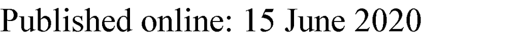

1.<sup>References</sup>

Cryan JF, Dinan TG. Mind-altering microorganisms: the impact of the gut

microbiota on brain and behaviour. Nat Rev Neurosci. 2012;13(10):701–12

https://doi.org/10.1038/nrn3346.

2.

Martin R, et al. Early-life events, including mode of delivery and type of

feeding, siblings and gender, shape the developing gut microbiota.

PLoS One. 2016;11(6):e0158498 https://doi.org/10.1371/journal.pone.

0158498.

3.

Cussotto S, Clarke G, Dinan TG, Cryan JF. Psychotropics and the

microbiome: a chamber of secrets …. Psychopharmacology. 2019;236(5):

1411–32 https://doi.org/10.1007/s00213-019-5185-8.

4.

Foster JA, McVey Neufeld K-A. Gut–brain axis: how the microbiome

influences anxiety and depression. Trends Neurosci. 2013;36(5):305–12

https://doi.org/10.1016/j.tins.2013.01.005.

5.

O’Hara AM, Shanahan F. The gut flora as a forgotten organ. EMBO Rep.

2006;7(7):688–93 https://doi.org/10.1038/sj.embor.7400731.

6.

Zhu B, Wang X, Li L. Human gut microbiome: the second genome of human

body. Protein Cell. 2010;1(8):718–25 https://doi.org/10.1007/s13238-010-0093-z.

7.

Stilling RM, Dinan TG, Cryan JF. Microbial genes, brain & behaviour –

epigenetic regulation of the gut–brain axis. Genes Brain Behav. 2014;13(1):

69–86 https://doi.org/10.1111/gbb.12109.

8.

Dash S, Clarke G, Berk M, Jacka FN. The gut microbiome and diet in

psychiatry: focus on depression. Curr Opin Psychiatry. 2015;28(1):1 https://

doi.org/10.1097/YCO.0000000000000117.

9.

Liu Y, et al. Similar fecal microbiota signatures in patients with diarrhea-

predominant irritable bowel syndrome and patients with depression. Clin

Gastroenterol Hepatol. 2016;14(11):1602–1611.e5 https://doi.org/10.1016/j.

cgh.2016.05.033.

10.

Sudo N, et al. Postnatal microbial colonization programs the hypothalamic–

pituitary–adrenal system for stress response in mice. J Physiol. 2004;558(Pt

1):263–75 https://doi.org/10.1113/jphysiol.2004.063388.

11.

Heijtz RD, et al. Normal gut microbiota modulates brain development and

behavior. Proc Natl Acad Sci U S A. 2011;108(7):3047–52 https://doi.org/10.

1073/pnas.1010529108.

12.

Neufeld KM, Kang N, Bienenstock J, Foster JA. Reduced anxiety-like behavior

and central neurochemical change in germ-free mice. Neurogastroenterol

Motil. 2011;23(3):255–e119 https://doi.org/10.1111/j.1365-2982.2010.01620.x.

13.

Zhang F, Luo W, Shi Y, Fan Z, Ji G. Should we standardize the 1,700-year-old

fecal microbiota transplantation? Am J Gastroenterol. 2012;107(11):1755

author reply p.1755–1756. https://doi.org/10.1038/ajg.2012.251.

Table 4 Clinical studies (Continued)

Study

Sample

characteristics

Study design

Intervention

Donor

Measurement

Key findings and conclusions

et al. 2020

[49]

constipated)

patients

between 18

and 75 years of

age

Randomized

Controlled Trial,

Parallel group

health donors or using

patient’s own feces,

delivered to cecum of IBS

patients via colonoscope

feces from

healthy donors

Impact Scale

(FIS), IBS-QoL,

IBS-SSS

six months after treatment, with

waning effect from six to twelve

months,

• Transient treatmnet effect seen in

individuals with other functional

disorders.

• Absence of other self reported

functional disorders and presence

of depression at baseline is

suggested to predict a lasting

effect of FMT in QoL and fatigue,

respectively

Chinna Meyyappan et al. BMC Psychiatry (2020) 20:299

Page 17 of 19

14.

de Groot PF, Frissen MN, de Clercq NC, Nieuwdorp M. Fecal microbiota

transplantation in metabolic syndrome: history, present and future. Gut

Microbes. 2017;8(3):253–67 https://doi.org/10.1080/19490976.2017.1293224.

15.

Huang H, et al. Fecal microbiota transplantation to treat Parkinson’s disease

with constipation: a case report. Medicine. 2019a;98(26):e16163 https://doi.

org/10.1097/MD.0000000000016163.

16.

Kang D-W, et al. Microbiota transfer therapy alters gut ecosystem and

improves gastrointestinal and autism symptoms: an open-label study.

Microbiome. 2017;5(1):10 https://doi.org/10.1186/s40168-016-0225-7.

17.

Makkawi S, Camara-Lemarroy C, Metz L. Fecal microbiota transplantation

associated with 10 years of stability in a patient with SPMS. Neurol

Neuroimmunol Neuroinflamm. 2018;5(4):e459 https://doi.org/10.1212/NXI.

0000000000000459.

18.

Meyyappan AC, Milev R. The safety, efficacy, and tolerability of microbial

ecosystem therapeutic-2 in people with major depression and/or

generalized anxiety disorder: phase 1, open label study protocol. JMIR Res

Protoc (forthcoming). https://doi.org/10.2196/17223.

19.

American Psychiatric Association. Depressive disorders and anxiety

disorders. In: Diagnostic and statistical manual of mental disorders. 5th ed.

Philadelphia: American Psychiatric Association; 2013. p. 93–128.

20.

Moher D, Liberati A, Tetzlaff J, Altman DG, PRISMA Group. Preferred reporting

items for systematic reviews and meta-analyses: the PRISMA statement. PLoS

Med. 2009;6(7):e1000097 https://doi.org/10.1371/journal.pmed.1000097.

21.

Li N, et al. Fecal microbiota transplantation from chronic unpredictable mild

stress mice donors affects anxiety-like and depression-like behavior in

recipient mice via the gut microbiota-inflammation-brain axis. Stress. 2019;

22(5):592–602 https://doi.org/10.1080/10253890.2019.1617267.

22.

Lv W, et al. The gut microbiome modulates the changes in liver metabolism

and in inflammatory processes in the brain of chronic unpredictable mild

stress rats. Oxidative Med Cell Longev. 2019;2019:1–14 https://doi.org/10.

1155/2019/7902874.

23.

Siopi E, et al. Changes in gut microbiota by chronic stress impair the

efficacy of fluoxetine. Cell Rep. 2020;30(11):3682–3690.e6 https://doi.org/10.

1016/j.celrep.2020.02.099.

24.

Pearson-Leary J, et al. The gut microbiome regulates the increases in

depressive-type behaviors and in inflammatory processes in the ventral

hippocampus of stress vulnerable rats. Mol Psychiatry. 2019;25:1–12 https://

doi.org/10.1038/s41380-019-0380-x.

25.

Langgartner D, et al. The role of the intestinal microbiome in chronic

psychosocial stress-induced pathologies in male mice. Front Behav

Neurosci. 2018;12:252 https://doi.org/10.3389/fnbeh.2018.00252.

26.

Alcocer-Gómez E, et al. NLRP3 inflammasome is activated in mononuclear

blood cells from patients with major depressive disorder. Brain Behav

Immun. 2014;36:111–7 https://doi.org/10.1016/j.bbi.2013.10.017.

27.

Zhang Y, et al. Involvement of inflammasome activation in

lipopolysaccharide-induced mice depressive-like behaviors. CNS Neurosci

Ther. 2014;20(2):119–24 https://doi.org/10.1111/cns.12170.

28.

Zhang Y, et al. Gut microbiota from NLRP3-deficient mice ameliorates

depressive-like behaviors by regulating astrocyte dysfunction via circHIPK2.

Microbiome. 2019;7(1):116 https://doi.org/10.1186/s40168-019-0733-3.

29.

Xiao H, et al. Gut microbiota modulates alcohol withdrawal-induced anxiety in

mice. Toxicol Lett. 2018;287:23–30 https://doi.org/10.1016/j.toxlet.2018.01.021.

30.

Jiang Y, Liu Y, Gao M, Xue M, Wang Z, Liang H. Nicotinamide riboside

alleviates alcohol-induced depression-like behaviours in C57BL/6J mice by

altering the intestinal microbiota associated with microglial activation and

BDNF expression. Food Funct. 2020;11(1):378–91 https://doi.org/10.1039/

C9FO01780A.

31.

Overstreet DH, Wegener G. The flinders sensitive line rat model of

depression--25 years and still producing. Pharmacol Rev. 2013;65(1):143–55

https://doi.org/10.1124/pr.111.005397.

32.

Tillmann S, Abildgaard A, Winther G, Wegener G. Altered fecal microbiota

composition in the Flinders sensitive line rat model of depression.

Psychopharmacology. 2019;236(5):1445–57 https://doi.org/10.1007/s00213-

018-5094-2.

33.

Schmidt EKA, Torres-Espin A, Raposo PJF, et al. Fecal transplant prevents gut

dysbiosis and anxiety-like behaviour after spinal cord injury in rats. PLoS

One. 2020;15(1):e0226128 https://doi.org/10.1371/journal.pone.0226128.

34.

Kelly JR, et al. Transferring the blues: depression-associated gut microbiota

induces neurobehavioural changes in the rat. J Psychiatr Res. 2016;82:109–

18 https://doi.org/10.1016/j.jpsychires.2016.07.019.

35.

Zheng P, et al. Gut microbiome remodeling induces depressive-like

behaviors through a pathway mediated by the host’s metabolism. Mol

Psychiatry. 2016;21(6):786–96 https://doi.org/10.1038/mp.2016.44.

36.

Huang C, et al. Proteomic analysis of olfactory bulb suggests CACNA1E as a

promoter of CREB signaling in microbiota-induced depression. J Proteome.

2019b;194:132–47 https://doi.org/10.1016/j.jprot.2018.11.023.

37.

Liu S, Guo R, Liu F, Yuan Q, Yu Y, Ren F. Gut microbiota regulates

depression-like behavior in rats through the neuroendocrine-immune-

mitochondrial pathway. Neuropsychiatr Dis Treat. 2020;16:859–69 https://

doi.org/10.2147/NDT.S243551.

38.

Petrakis IL, Gonzalez G, Rosenheck R, Krystal JH. Comorbidity of alcoholism

and psychiatric disorders. Alcohol Res Health. 2002;26(2):81–9.

39.

Zhao W, et al. Transplantation of fecal microbiota from patients with

alcoholism induces anxiety/depression behaviors and decreases brain

mGluR1/PKC ε levels in mouse; 2019. p. 17.

40.

Xu Z, et al. Fecal microbiota transplantation from healthy donors reduced

alcohol-induced anxiety and depression in an animal model of chronic

alcohol exposure. Chin J Phys. 2018;61(6):360–71.

41.

Hudson JI, Hiripi E, Pope HG, Kessler RC. The prevalence and correlates of

eating disorders in the National Comorbidity Survey Replication. Biol

Psychiatry. 2007;61(3):348–58 https://doi.org/10.1016/j.biopsych.2006.03.040.

42.

Hata T, et al. The gut microbiome derived from anorexia nervosa patients

impairs weight gain and behavioral performance in female mice.

Endocrinology. 2019;160(10):2441–52 https://doi.org/10.1210/en.2019-00408.

43.

De Palma G, et al. Transplantation of fecal microbiota from patients with

irritable bowel syndrome alters gut function and behavior in recipient mice.

Sci Transl Med. 2017;9(379):eaaf6397 https://doi.org/10.1126/scitranslmed.

aaf6397.

44.

Mizuno S, et al. Bifidobacterium-rich fecal donor may be a positive predictor

for successful fecal microbiota transplantation in patients with irritable

bowel syndrome. Digestion. 2017;96(1):29–38 https://doi.org/10.1159/

000471919.

45.

Huang HL, et al. Relief of irritable bowel syndrome by fecal microbiota

transplantation is associated with changes in diversity and composition of

the gut microbiota. J Dig Dis. 2019c;20(8):401–8 https://doi.org/10.1111/

1751-2980.12756.

46.

Mazzawi T, et al. The kinetics of gut microbial community composition in

patients with irritable bowel syndrome following fecal microbiota

transplantation. PLoS ONE. 2018;13(11):e0194904 https://doi.org/10.1371/

journal.pone.0194904.

47.

Xie W-R, Yang X-Y, Xia HH-X, Wu L-H, He X-X. Hair regrowth following fecal

microbiota transplantation in an elderly patient with alopecia areata: a case

report and review of the literature. World J Clin Cases. 2019;7(19):3074–81

https://doi.org/10.12998/wjcc.v7.i19.3074.

48.

Kurokawa S, et al. The effect of fecal microbiota transplantation on psychiatric

symptoms among patients with irritable bowel syndrome, functional diarrhea

and functional constipation: an open-label observational study. J Affect Disord.

2018;235:506–12 https://doi.org/10.1016/j.jad.2018.04.038.

49.

Johnsen PH, Hilpüsch F, Valle PC, Goll R. The effect of fecal microbiota

transplantation on IBS related quality of life and fatigue in moderate to

severe non-constipated irritable bowel: secondary endpoints of a double

blind, randomized, placebo-controlled trial. EBioMedicine. 2020;51:102562

https://doi.org/10.1016/j.ebiom.2019.11.023.

50.

Treviño LA, Ruble MW, Treviño K, Weinstein LM, Gresky DP. Antidepressant

medication prescribing practices for treatment of major depressive disorder.

Psychiatr Serv. 2017;68(2):199–202 https://doi.org/10.1176/appi.ps.201600087.

51.

Gershon MD. 5-Hydroxytryptamine (serotonin) in the gastrointestinal tract.

Curr Opin Endocrinol Diab Obes. 2013;20(1):14–21 https://doi.org/10.1097/

MED.0b013e32835bc703.

52.

Reigstad CS, et al. Gut microbes promote colonic serotonin production

through an effect of short-chain fatty acids on enterochromaffin cells.

FASEB J. 2015;29(4):1395–403 https://doi.org/10.1096/fj.14-259598.

53.

Silva YP, Bernardi A, Frozza RL. The role of short-chain fatty acids from gut

microbiota in gut-brain communication. Front Endocrinol. 2020;11:25

https://doi.org/10.3389/fendo.2020.00025.

54.

van de Wouw M, et al. Short-chain fatty acids: microbial metabolites that

alleviate stress-induced brain–gut axis alterations. J Physiol. 2018;596(20):

4923–44 https://doi.org/10.1113/JP276431.

55.

Singh N, et al. Activation of Gpr109a, receptor for niacin and the

commensal metabolite butyrate, suppresses colonic inflammation and

Chinna Meyyappan et al. BMC Psychiatry (2020) 20:299

Page 18 of 19

carcinogenesis. Immunity. 2014;40(1):128–39 https://doi.org/10.1016/j.

immuni.2013.12.007.

56.

Erny D, et al. Host microbiota constantly control maturation and function of

microglia in the CNS. Nat Neurosci. 2015;18(7):965–77 https://doi.org/10.

1038/nn.4030.

57.

Bauer ME, Teixeira AL. Inflammation in psychiatric disorders: what comes first?

Ann N Y Acad Sci. 2019;1437(1):57–67 https://doi.org/10.1111/nyas.13712.

58.

Inserra A, Rogers GB, Licinio J, Wong M-L. The microbiota-inflammasome

hypothesis of major depression. Bioessays. 2018;40(9):e1800027 https://doi.

org/10.1002/bies.201800027.

59.

Bonaz B, Bazin T, Pellissier S. The vagus nerve at the interface of the

microbiota-gut-brain axis. Front Neurosci. 2018;12:49 https://doi.org/10.

3389/fnins.2018.00049.

60.

Breit S, Kupferberg A, Rogler G, Hasler G. Vagus nerve as modulator of the

brain–gut axis in psychiatric and inflammatory disorders. Front Psychiatry.

2018;9:44 https://doi.org/10.3389/fpsyt.2018.00044.

61.

Garcia-Toro M, Medina E, Galan JL, Gonzalez MA, Maurino J. Treatment

patterns in major depressive disorder after an inadequate response to first-

line antidepressant treatment. BMC Psychiatry. 2012;12:143 https://doi.org/

10.1186/1471-244X-12-143.

62.

Stahl SM. Mechanism of action of serotonin selective reuptake inhibitors.

Serotonin receptors and pathways mediate therapeutic effects and side

effects. J Affect Disord. 1998;51(3):215–35 https://doi.org/10.1016/s0165-

0327(98)00221-3.

63.

Lloyd-Price J, Abu-Ali G, Huttenhower C. The healthy human microbiome.

Genome Med. 2016;8(1) https://doi.org/10.1186/s13073-016-0307-y.

64.

Turnbaugh PJ, Ley RE, Hamady M, Fraser-Liggett CM, Knight R, Gordon JI.

The human microbiome project. Nature. 2007;449(7164):804–10 https://doi.

org/10.1038/nature06244.

65.

Huttenhower C, et al. Structure, function and diversity of the healthy human

microbiome. Nature. 2012;486(7402):207–14 https://doi.org/10.1038/

nature11234.

66.

Cai T, Shi X, Yuan L, Tang D, Wang F. Fecal microbiota transplantation in an

elderly patient with mental depression. Int Psychogeriatr. 2019;31(10):1525–

6 https://doi.org/10.1017/S1041610219000115.

67.

de Clercq NC, Frissen MN, Davids M, Groen AK, Nieuwdorp M. Weight Gain

after Fecal Microbiota Transplantation in a Patient with Recurrent

Underweight following Clinical Recovery from Anorexia Nervosa. Psychother

Psychosom. 2019;88(1):58–60 https://doi.org/10.1159/000495044.

68.

Yang C, et al. Key role of gut microbiota in anhedonia-like phenotype in

rodents with neuropathic pain. Transl Psychiatry. 2019;9(1):1–11 https://doi.

org/10.1038/s41398-019-0379-8.

69.

Chen K, Fu Y, Wang Y, et al. Therapeutic Effects of the In Vitro Cultured

Human Gut Microbiota as Transplants on Altering Gut Microbiota and

Improving Symptoms Associated with Autism Spectrum Disorder. Microb

Ecol. 2020; https://doi.org/10.1007/s00248-020-01494-w.

Publisher’s Note

Springer Nature remains neutral with regard to jurisdictional claims in

published maps and institutional affiliations.

Chinna Meyyappan et al. BMC Psychiatry (2020) 20:299

Page 19 of 19